# Отчёт по прохождению 3 этапа внешнего курса

Uuuubuntu! — не подходит из-за ! (конец строки) (рис. 28).

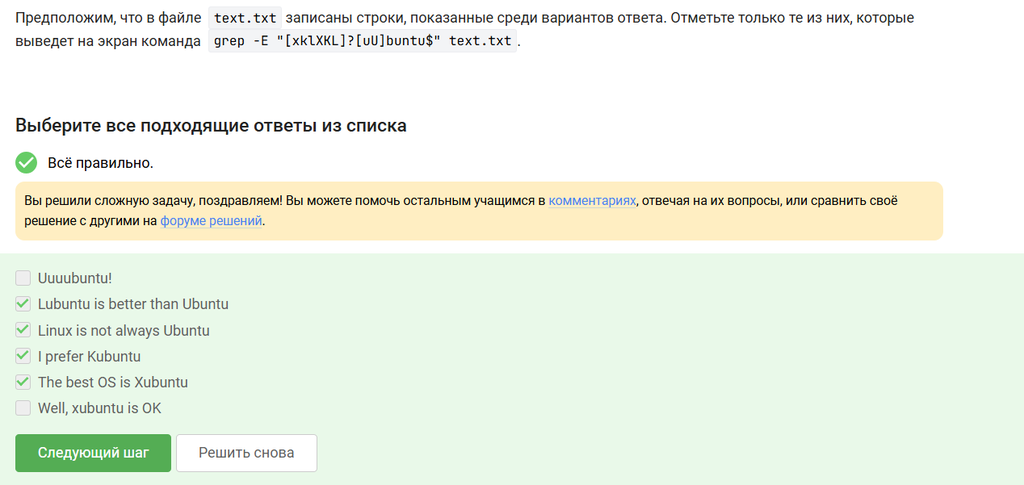

Рисунок 28: 25 задание

Без -n sed печатает каждую строку автоматически. Команда p печатает ещё раз. Итого 2 раза.(рис. 29).

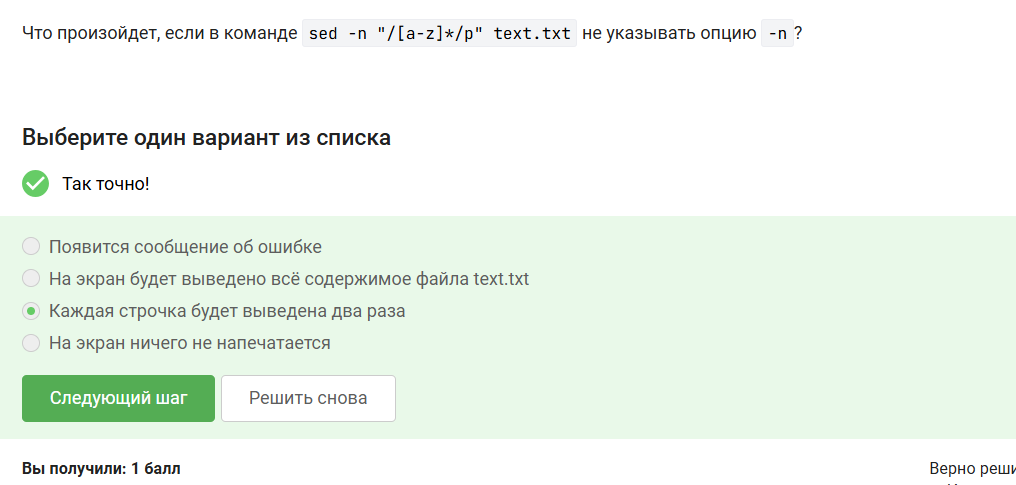

Рисунок 29: 26 задание

Тут [A-Z] — большие буквы, {2,} — от 2 и более, пробел после — окружение справа. Замена с пробелом сохраняет форматирование (рис. 30).

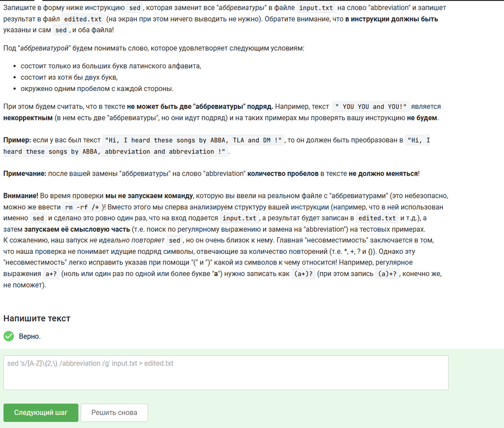

Рисунок 30: 27 задание

Опция –persist оставляет окна графиков после выхода из gnuplot (рис. 31).

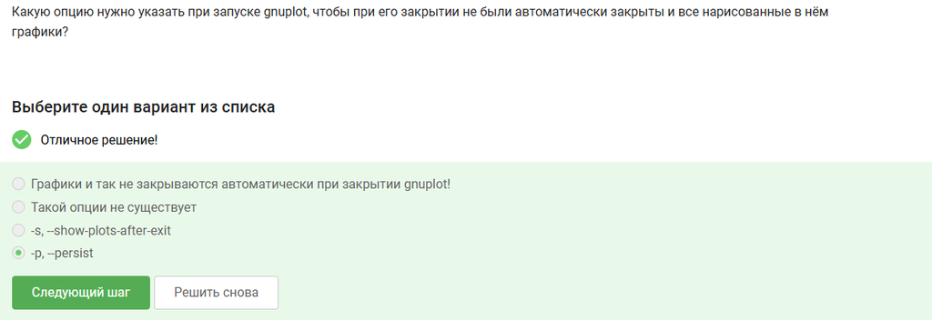

Рисунок 31: 28 задание

set key autotitle columnhead берёт заголовок из первого значения второго столбца (первая строка). Первая строка данных не рисуется, только 9 точек.(рис. 32).

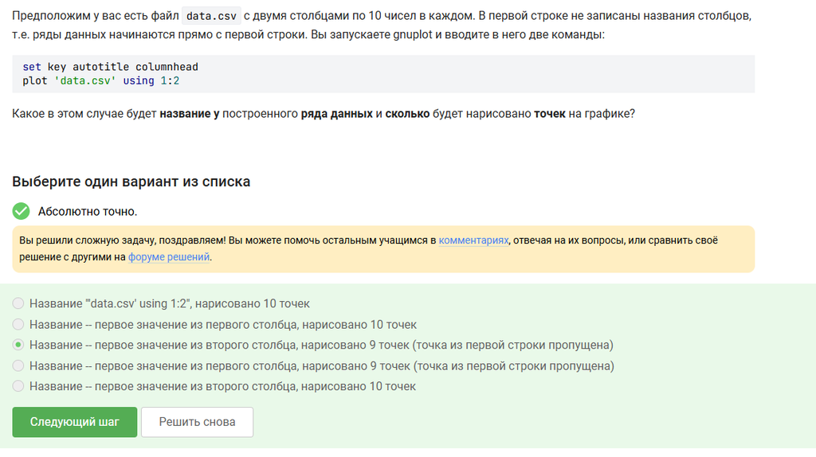

Рисунок 32: 29 задание

set xtics — устанавливает деления на оси X

(“point 1, value”.x1) x1 — метка “point 1, value <значение x1>” в координате x1

, — разделитель

(“point 2, value”.x2) x2 — метка в координате x2

(“point 3, value”.x3) x3 — метка в координате x3

. — конкатенация (склеивание строк) (рис. 33).

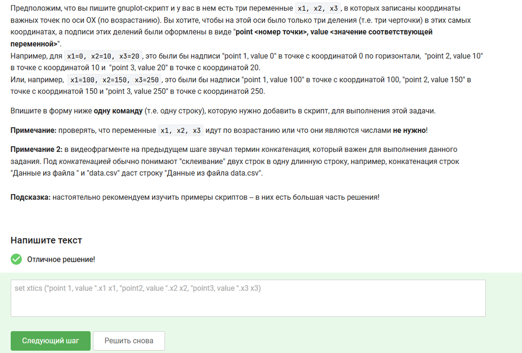

Рисунок 33: 30 задание

Правильный текст:

text a=a+1 zrot=(zrot-20)%360 set view xrot,zrot splot -(x**2+y**2) pause 0.2 if (a<50) reread

Пояснение:

- -(x**2+y**2) — отражение по горизонтали (Z).
- -20 вместо +10 — обратное вращение и ускорение (20 — в 2 раза быстрее 10) рис. 34).

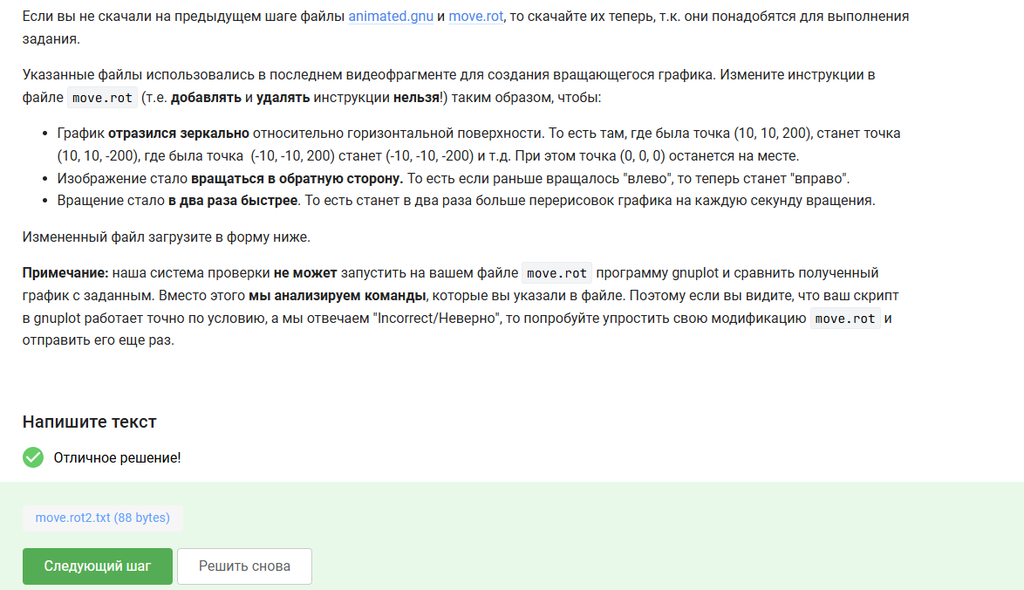

Рисунок 34: 31 задание

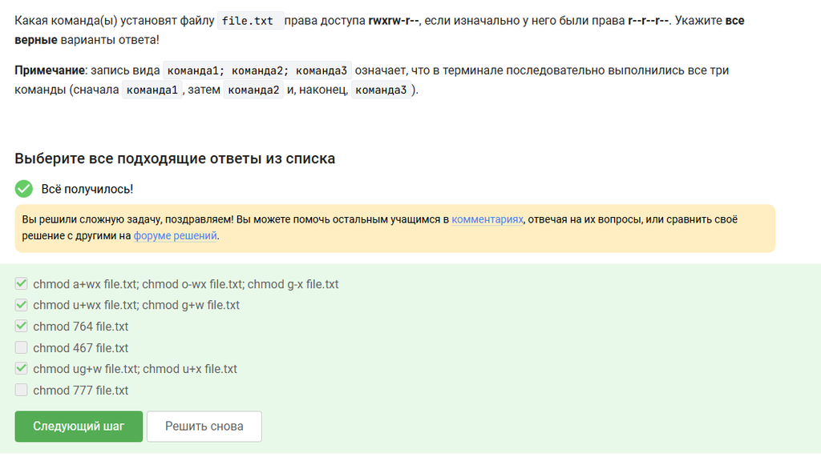

Рисунок 35: 32 задание

- (sudo chmod a+w dir) — даёт запись всем, включая user.
- (sudo chown user.group dir) — user становится владельцем → может писать.
- (sudo chown user dir) — user владелец → может писать.
- sudo chmod o+x — даёт выполнение, не запись.
- chmod o+w (без sudo) — нет прав менять.
- sudo chmod g+w — группа root, а user в ней не состоит (рис. 36).

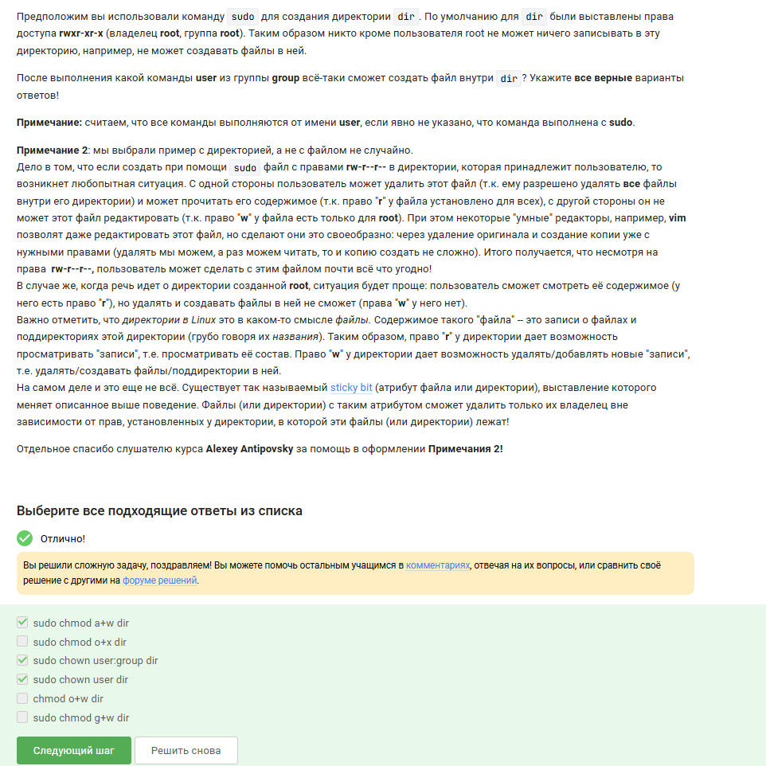

Рисунок 36: 33 задание

wc умеет считать: количество строк (-l), количество слов (-w), количество символов (-m) или байт (-c). Количество предложений и определенных букв не умеет (рис. 37).

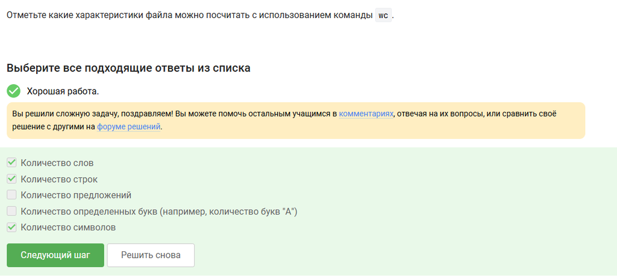

Рисунок 37: 34 задание

du - показывает размер файлов и директории. -h - выводит размер в удобном формате. -s - показывает только общий размер текущей директории, без перечисления вложенных файлов и поддиректорий (рис. 38).

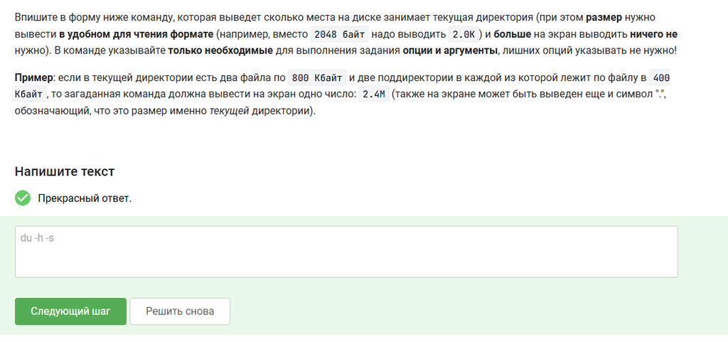

Рисунок 38: 35 задание

mrdir - создает директории. {1..3} - фигурные скобки раскрываются в 1 2 3. dir{1..3} превращается в dir1 dir 2 dir 3 (рис. 39).

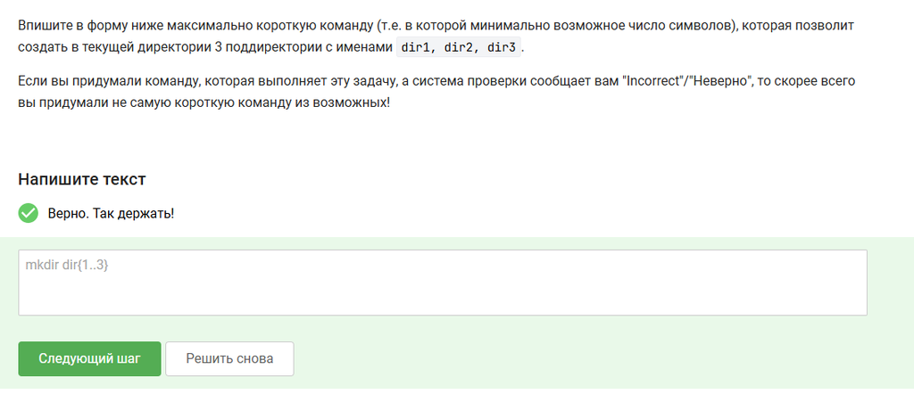

Рисунок 39: 36 задание

Я получила сертификат о прохождении курса (рис. 40).

[figure not shown]

Рисунок 40: Сертификат

# Выводы

Я успешно прошла 3 этап курса “Введение в Linux” на платформе Stepik и ознакомилась с функционалом Linux, а также получила сертификат об окончании курса.

# Список литературы

[Введение в Linux](https://stepik.org/course/73/syllabus)